| SOC 106 Final Exam Key May 11, 2026 | **Name:** ________________________________ |
| --- | --- |

**Directions:** This is a closed-book, closed-computer final exam. You have a total of 3 hours to complete the exam, but it may not necessarily take the entire exam period. For the multiple-choice section, circle the best answer; for each short-answer question, be sure to answer all parts (`a-c`, where applicable) and provide all information requested. All output you need has been provided, and there is a reference sheet on the last page with any additional information/formulas you might need. Each multiple-choice question is worth 0.5 points and each short-answer question is worth 1.5 points, for a total of 20 points on the exam.

# Section I: Multiple Choice

For each question, circle the best answer. There are 10 questions total, each worth 0.5 points, for a total of 5 points.

**Question 1.** A researcher records each respondent’s highest educational attainment using four categories: **HS or less**, **Some college**, **College graduate**, and **Graduate degree**. What type of variable is this?

A. Continuous  
B. Binary categorical  
C. Ordinal categorical  
D. Count

**Correct answer: C.** These categories have a natural order from lower to higher educational attainment, so this is an ordinal categorical variable.

**Question 2.** Suppose you are asked to model whether a respondent is a homeowner (`1 = yes`, `0 = no`) using a model designed for a binary outcome. Which probability distribution is the most appropriate?

A. Normal  
B. Binomial  
C. Poisson  
D. Uniform

**Correct answer: B.** A yes-or-no outcome is binary, so the binomial distribution is the most appropriate choice.

**Question 3.** Look at the four miniature distributions below. Which panel shows a **left-skewed** distribution?

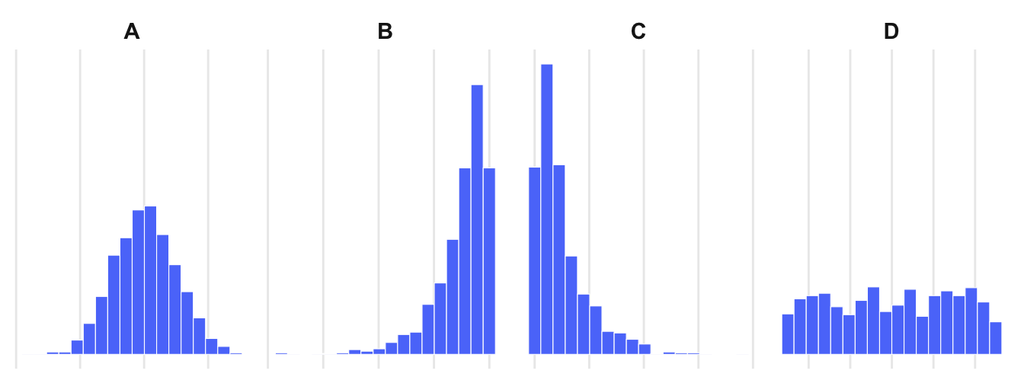

A. Panel A  
B. Panel B  
C. Panel C  
D. Panel D

**Correct answer: B.** Panel B has most observations concentrated at higher values with a longer tail stretching to the left.

**Question 4.** Which statement best describes the Central Limit Theorem?

A. With a large enough random sample, the sampling distribution of the sample mean becomes approximately normal even if the population itself is not normal  
B. Any single large sample will always look perfectly normal  
C. The population must be normal before you can estimate a mean  
D. Increasing the sample size makes all estimates unbiased

**Correct answer: A.** The CLT is about the sampling distribution of sample means, not the shape of every raw sample.

**Question 5.** Under a normal curve, about what proportion of observations fall within two standard deviations of the mean?

A. About 68 percent  
B. About 80 percent  
C. About 95 percent  
D. About 99.7 percent

**Correct answer: C.** The 68-95-99.7 rule says about 95 percent of observations fall within two standard deviations of the mean.

**Question 6.** You want to show the distribution of a categorical variable such as marital status. Which figure is usually the best choice?

A. Histogram  
B. Scatterplot  
C. Bar chart  
D. Boxplot

**Correct answer: C.** Bar charts are the standard choice for showing counts or proportions for categorical variables.

**Question 7.** A researcher uses 1,500 GSS respondents to estimate the national homeownership rate. Which pair of terms correctly describes the 1,500 respondents and all U.S. adults, respectively?

A. Population; sample  
B. Sample; population  
C. Parameter; statistic  
D. Statistic; parameter

**Correct answer: B.** The observed respondents are the sample, and the broader group the researcher wants to generalize to is the population.

**Question 8.** A researcher wants to test whether Black adults and white adults report different mean occupational prestige scores. Which hypothesis test is the most appropriate?

A. Chi-square test of independence B. One-sample t-test C. Two-sample t-test D. Correlation test

**Correct answer: C.** A two-sample t-test compares the means of two groups on a quantitative outcome.

**Question 9.** A p-value of 0.03 means:

A. There is a 3 percent chance the null hypothesis is false  
B. If the null hypothesis were true, there would be a 3 percent chance of observing results at least this extreme  
C. The alternative hypothesis is true with 97 percent probability  
D. Exactly 3 percent of the sample supports the null hypothesis

**Correct answer: B.** This matches the course phrasing that a p-value is the probability of observing results at least this extreme, assuming the null hypothesis is true.

**Question 10.** What does an `R^2` statistic tell you in an OLS regression?

A. Whether each coefficient is statistically significant  
B. The exact causal effect of the key independent variable  
C. The proportion of the variation in the outcome explained by the model  
D. The probability that the null hypothesis is true

**Correct answer: C.** R-squared tells you how much of the variation in the outcome is explained by the model.

# Section II: Short Answer

For each question, be sure to answer all parts (`a-c`) and provide all information requested. There are a total of 10 questions, with each question worth 1.5 points, for a total of 15 points.

**Question 11. Two-Sample t-Test (1.5 points)**

A researcher wants to know whether men and women reported different average hours worked last week in the 2024 GSS. The following output summarizes a two-sample t-test comparing mean hours worked across the two groups.

```
Two Sample t-test

data: hrs1 by sex
t = -6.46, df = 2186, p-value < 0.001
alternative hypothesis: true difference in mean is not equal to 0
95 percent confidence interval:
 -6.95 -3.71
sample estimates:
mean in group Men   42.5
mean in group Women 37.2
```

**a)** Which group worked more hours on average, and by about how many hours?

**Template answer:** Men worked more hours on average. The mean was 42.5 hours for men and 37.2 hours for women, so the gap is about 5.3 hours.

*Rubric:* 0.5 points for identifying men as the higher-mean group and describing the gap as about 5.3 hours.

**b)** Is the difference statistically significant at the 0.05 level? Briefly explain how you know this.

**Template answer:** Yes. The p-value is < 0.001, which is below 0.05, and the 95 percent confidence interval for the difference does not include 0, so we would reject the null hypothesis of no mean difference.

*Rubric:* 0.5 points for stating that the result is statistically significant and linking that conclusion to the p-value or confidence interval.

**c)** Write 1-2 sentences interpreting what these results mean in substantive terms.

**Template answer:** In this sample, men reported working more hours last week than women. The gap is statistically significant and substantively noticeable, at a little over five hours on average.

*Rubric:* 0.5 points for a clear substantive interpretation that identifies both the direction and size of the difference.

**Question 12. OLS with a Categorical Predictor (1.5 points)**

A researcher wants to know whether occupational prestige differs across educational attainment, controlling for age and sex. Table 2 reports an OLS model predicting occupational prestige (`prestg10`) from educational attainment, age, and sex. Education has been grouped into four categories: **HS or less**, **Some college**, **College graduate**, and **Graduate degree**.

Table 2. OLS model predicting occupational prestige

| Term | Prestige score |
| --- | --- |
| Intercept | 46.76*** |
|  | (0.71) |
| Age | 0.09*** |
|  | (0.01) |
| Female (1 = yes) | -0.92* |
|  | (0.39) |
| HS or less | -13.70*** |
|  | (0.54) |
| Some college | -8.58*** |
|  | (0.56) |
| Graduate degree | 2.77*** |
|  | (0.63) |
| Num. Obs. | 3611 |
| R2 | 0.259 |
| Adj. R2 | 0.258 |
| AIC | 29492.7 |

Note. * p < .05, ** p < .01, *** p < .001.

**a)** Which education category is the baseline/reference group in this model? How can you tell?

**Template answer:** College graduate is the baseline/reference group because it is omitted from the coefficient list and absorbed into the intercept.

*Rubric:* 0.5 points for correctly identifying college graduate as the baseline/reference category.

**b)** Interpret the coefficient for **HS or less**.

**Template answer:** Holding age and sex constant, respondents with HS or less are predicted to score about 13.70 points lower on occupational prestige than college graduates.

*Rubric:* 0.5 points for interpreting the HS or less coefficient relative to the college graduate baseline.

**c)** What does the `R^2` tell you about this model?

**Template answer:** The R2 is about 0.26, which means the model explains roughly 25.9 percent of the variation in occupational prestige.

*Rubric:* 0.5 points for interpreting R2 as the share of variation in the outcome explained by the model.

**Question 13. Logistic Regression in Odds Ratios (1.5 points)**

A researcher wants to know whether homeownership is related to education, age, and sex. Table 3 reports a logistic regression predicting homeownership. Coefficients are shown as odds ratios.

Table 3. Logistic regression predicting homeownership

| Term | Odds ratio |
| --- | --- |
| Intercept | 0.08*** |
|  | (0.02) |
| Education (years) | 1.13*** |
|  | (0.02) |
| Age | 1.04*** |
|  | (0.00) |
| Female (1 = yes) | 0.72*** |
|  | (0.07) |
| Num. Obs. | 2489 |
| AIC | 2738.1 |

Note. * p < .05, ** p < .01, *** p < .001.

**a)** Interpret the odds ratio for **Education (years)**.

**Template answer:** Holding age and sex constant, each additional year of education is associated with odds of homeownership that are about 13.2 percent higher.

*Rubric:* 0.5 points for interpreting the education odds ratio as an increase in the odds of homeownership.

**b)** Interpret the odds ratio for **Age**.

**Template answer:** Holding education and sex constant, each additional year of age is associated with odds of homeownership that are about 3.7 percent higher.

*Rubric:* 0.5 points for interpreting the age odds ratio as a positive increase in the odds of homeownership.

**c)** Interpret the odds ratio for **Female (1 = yes)**.

**Template answer:** Holding education and age constant, women have odds of homeownership that are about 28.0 percent lower than men.

*Rubric:* 0.5 points for identifying men as the reference group and correctly interpreting the direction of the odds ratio.

**Question 14. Interaction with Two Continuous Variables (1.5 points)**

A researcher wants to know whether the relationship between education and hours worked last week depends on age. Table 4 reports an OLS model predicting hours worked from education, age, sex, and an education-age interaction.

Table 4. OLS model with an education x age interaction

| Term | Hours worked |
| --- | --- |
| Intercept | 25.87*** |
|  | (5.08) |
| Education (years) | 1.19*** |
|  | (0.35) |
| Age | 0.40*** |
|  | (0.11) |
| Education x Age | -0.03*** |
|  | (0.01) |
| Female (1 = yes) | -5.18*** |
|  | (0.59) |
| Num. Obs. | 2120 |
| R2 | 0.041 |
| Adj. R2 | 0.039 |
| AIC | 18045.7 |

Note. * p < .05, ** p < .01, *** p < .001.

**a)** Is the interaction statistically significant and how do you know?

**Template answer:** Yes. The interaction is statistically significant because the education-age term has asterisks next to the coefficient in the table, indicating p < .05 or smaller.

*Rubric:* 0.5 points for stating that the interaction is statistically significant and explaining that the stars or p-value show this.

**b)** Based on the sign of the interaction term, does the association between education and hours worked become stronger or weaker as age increases?

**Template answer:** It becomes weaker as age increases. The negative interaction means the slope of education gets smaller, and eventually more negative, at older ages.

*Rubric:* 0.5 points for recognizing that the negative interaction implies a weaker education-hours relationship at older ages.

**c)** Write one substantive sentence interpreting the interaction.

**Template answer:** The association between education and hours worked depends on age: education is linked to slightly more hours among younger adults, but that relationship weakens and can turn negative at older ages.

*Rubric:* 0.5 points for a clear substantive interpretation of the continuous-by-continuous interaction.

**Question 15. Interaction with One Categorical Variable (1.5 points)**

A researcher wants to know whether the association between education and occupational prestige differs between married respondents and respondents who are not married. Table 5 reports an OLS model predicting occupational prestige from education, marital status, age, sex, and an education-married interaction.

Table 5. OLS model with an education x married interaction

| Term | Prestige score |
| --- | --- |
| Intercept | 10.95*** |
|  | (1.48) |
| Age | 0.09*** |
|  | (0.01) |
| Female (1 = yes) | -0.62 |
|  | (0.39) |
| Education (years) | 1.99*** |
|  | (0.10) |
| Married (1 = yes) | -2.01 |
|  | (1.99) |
| Education x Married | 0.28* |
|  | (0.14) |
| Num. Obs. | 3604 |
| R2 | 0.245 |
| Adj. R2 | 0.244 |
| AIC | 29501.2 |

Note. * p < .05, ** p < .01, *** p < .001.

**a)** What does the coefficient on **Education (years)** tell you?

**Template answer:** Among respondents who are not married, each additional year of education is associated with about 1.99 more points of occupational prestige, holding age and sex constant.

*Rubric:* 0.5 points for interpreting the education lower-order term for the reference group.

**b)** What does the coefficient on **Married (1 = yes)** tell you in this uncentered model?

**Template answer:** Because this model is not centered, the married coefficient is the predicted married-versus-not-married difference when education equals 0. At that value, married respondents are predicted to score about 2.01 points lower on occupational prestige than respondents who are not married, holding age and sex constant.

*Rubric:* 0.5 points for interpreting the married lower-order term in the uncentered model.

**c)** Interpret the interaction, including both the lower-order terms and the higher-order term.

**Template answer:** For respondents who are not married, the education slope is about 1.99 prestige points per additional year of education. For married respondents, the slope is steeper by about 0.28 points, so their education slope is about 2.27. In other words, the prestige gap associated with education grows faster among married respondents.

*Rubric:* 0.5 points for using the lower-order and higher-order terms together to explain how the education slope differs by marital status.

**Question 16. Margins Plot (1.5 points)**

Figure 1 shows predicted hours worked from the model shown in Table 4, in which the relationship between education and hours worked is allowed to vary by age. The lines are shown for ages 30, 45, and 60, holding sex constant.

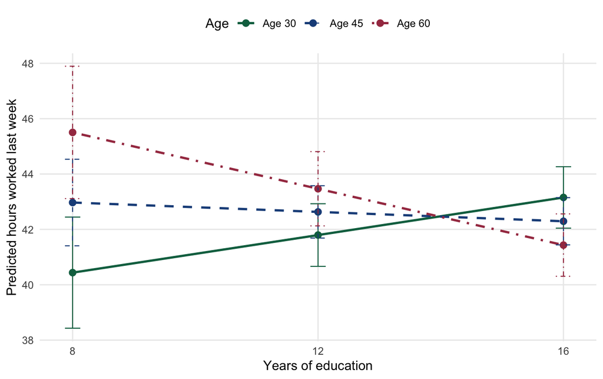

**a)** Describe the pattern for respondents age 30 as education increases.

**Template answer:** For respondents age 30, predicted hours worked increase as education rises, from about 40.4 hours at 8 years of education to about 43.2 hours at 16 years.

*Rubric:* 0.5 points for identifying the upward pattern for the age-30 line.

**b)** Describe the pattern for respondents age 60 as education increases.

**Template answer:** For respondents age 60, predicted hours worked decrease as education rises, from about 45.5 hours at 8 years of education to about 41.4 hours at 16 years.

*Rubric:* 0.5 points for identifying the downward pattern for the age-60 line.

**c)** What does the pattern of the lines suggest about moderation?

**Template answer:** The lines are not parallel, so the plot suggests moderation: the relationship between education and hours worked changes across age groups.

*Rubric:* 0.5 points for connecting non-parallel lines to moderation.

**Question 17. Sampling Design (1.5 points)**

A research team wants to estimate the share of U.S. adults who are currently employed full-time. Rather than drawing names from a complete list of all U.S. adults, they divide the country into geographic regions, randomly select 50 regions, and then attempt to interview every adult they can reach within each selected region. They are only able to reach adults who are home during weekday business hours.

**a)** What type of probability sampling design does this describe? Briefly explain how you identified it.

**Template answer:** This is cluster sampling. The sampling unit is a geographic area (cluster) rather than an individual; all reachable adults within each selected cluster are interviewed.

*Rubric:* 0.5 points for correctly naming cluster sampling and briefly explaining why.

**b)** What type of bias does restricting interviews to weekday business hours introduce, and why is it a problem for this particular study?

**Template answer:** This introduces non-response bias (or selection bias). Adults who are home on weekday mornings or afternoons are systematically different from those who are not — people employed full-time are far less likely to be reachable, so the sample will underrepresent full-time workers and likely underestimate the full-time employment rate.

*Rubric:* 0.5 points for identifying non-response or selection bias and explaining that employed adults are systematically less reachable.

**c)** In 1–2 sentences, explain what it would mean for the final sample to be **representative** of the U.S. adult population.

**Template answer:** A representative sample is one whose characteristics — such as age, sex, race, region, and employment status — closely mirror those of the broader U.S. adult population, so that estimates from the sample can be generalized to all U.S. adults.

*Rubric:* 0.5 points for defining representativeness in terms of the sample’s characteristics matching the population.

**Question 18. Mediation or Moderation? (1.5 points)**

A researcher first finds that education is positively associated with homeownership. After adding income to the model, the coefficient for education becomes much smaller. The researcher argues that part of the association between education and homeownership operates through income.

**a)** Is this pattern more consistent with **mediation** or **moderation**?

**Template answer:** This pattern is more consistent with mediation.

*Rubric:* 0.5 points for correctly identifying the pattern as mediation.

**b)** Explain why in 1-2 sentences.

**Template answer:** It is mediation because income is being treated as the mechanism that helps carry the effect of education to homeownership. The key clue is that the education coefficient shrinks after income is added, which is consistent with a pathway story rather than a different-effect-for-different-groups story.

*Rubric:* 0.5 points for explaining that income is the mechanism or pathway linking education to homeownership.

**c)** Draw a simple path diagram with arrows to show the claim.

**Template answer:** Education -> Income -> Homeownership

*Rubric:* 0.5 points for a correct path diagram showing income between education and homeownership.

**Question 19. Figure Critique (1.5 points)**

Figure 2 contains several presentation problems.

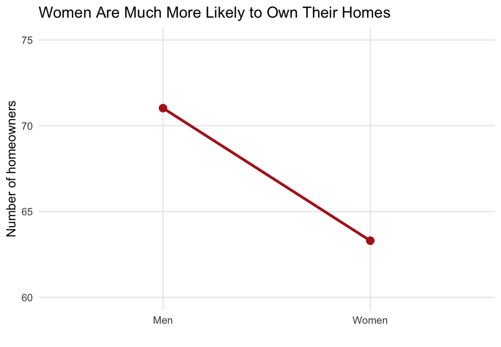

**a)** Identify one problem with the figure and briefly explain why it is a problem.

**Template answer:** One problem is that it uses a line graph for a categorical x-axis (men versus women), when a bar chart or clearly labeled points would be more appropriate.

*Rubric:* 0.5 points for identifying one genuine design problem and explaining it.

**b)** Identify a second problem with the figure and briefly explain why it is a problem.

**Template answer:** A second problem is that the y-axis starts at 60 instead of 0, which exaggerates the apparent difference between the two groups.

*Rubric:* 0.5 points for identifying a second genuine design problem and explaining it.

**c)** Identify a third problem with the figure and briefly explain why it is a problem.

**Template answer:** A third problem is that the title is misleading because it claims women are much more likely to own homes even though the plotted values show the opposite pattern. Another acceptable answer is that the y-axis label says ‘Number of homeowners’ even though the graph shows percentages.

*Rubric:* 0.5 points for identifying a third genuine design problem and explaining it.

**Question 20. Confidence Interval Interpretation (1.5 points)**

A researcher wants to estimate the share of adults in the population who are currently married. Table 7 reports the point estimate and confidence interval.

Table 7. Estimated share of adults who are currently married

| Point estimate | 95% confidence interval |
| --- | --- |
| 51.1% | [48.8%, 53.3%] |

**a)** What does the point estimate mean in words?

**Template answer:** The point estimate means that about 51.1% of adults are estimated to be currently married.

*Rubric:* 0.5 points for correctly stating what the point estimate represents.

**b)** Interpret the 95 percent confidence interval in plain language.

**Template answer:** We are 95 percent confident that the true population share of adults who are currently married is between 48.8% and 53.3%.

*Rubric:* 0.5 points for a correct plain-language interpretation of the interval.

**c)** If the sample size were larger, holding everything else constant, would you expect the interval to become wider or narrower? Why?

**Template answer:** It would usually become narrower because a larger sample size reduces sampling variability, which shrinks the standard error and the margin of error.

*Rubric:* 0.5 points for stating that the interval would narrow and linking that to a smaller standard error or margin of error.